# Hw 4 Rewrite

Runan Yao

October 1, 2018

# 1. Load Data

```r
data <- read.csv('GSE37704.csv')
rownames(data) <- gsub(" ","",data[,1])
data <- data[,-1]

colna <- colnames(data)
coldata <- as.data.frame(c('control','control','control','Hoxa1KN','Hoxa1KN','Hoxa1KN'))
colnames(coldata) <- c('condition')
rownames(coldata) <- colna
```

# 2. Cut Data ( Pre-filtering )

by [pre-filtering section in DESeq2 Manual](http://bioconductor.org/packages/devel/bioc/vignettes/DESeq2/inst/doc/DESeq2.html#pre-filtering) >Pre-filtering While it is not necessary to pre-filter low count genes before running the DESeq2 functions, there are two reasons which make pre-filtering useful: by removing rows in which there are very few reads, we reduce the memory size of the dds data object, and we increase the speed of the transformation and testing functions within DESeq2. Here we perform a minimal pre-filtering to keep only rows that have at least 10 reads total. Note that more strict filtering to increase power is automatically applied via independent filtering on the mean of normalized counts within the results function. > >keep <- rowSums(counts(dds)) >= 10 > >dds <- dds[keep,]

```r
dds <- DESeqDataSetFromMatrix(countData = as.matrix(data), colData = coldata, design = ~ condition )
dds <- DESeq(dds)
dds <- dds[ rowSums( counts(dds) >= 5 ) >= 1 ]
```

# 3. Do log transform and vst transform

```r
rlog.dds <- rlog(dds, blind = FALSE)
vsd <- vst(dds, blind = FALSE)
```

## 3.1 PCA

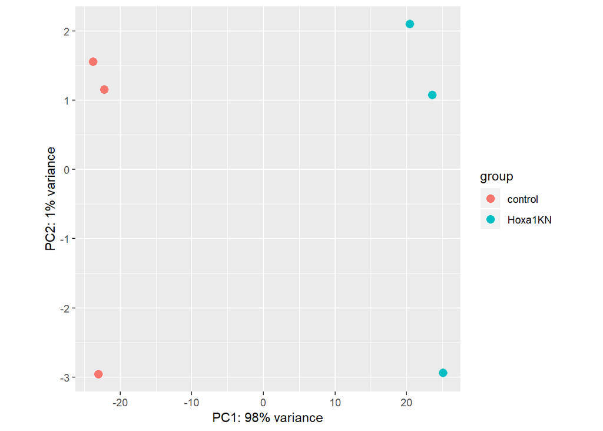

```r
plotPCA(rlog.dds)+ theme(aspect.ratio=1)
```

## 3.2 Histgram

### Cluster function and distance function

```r
hclust2 <- function(x, method="average", ...)
  hclust(x, method=method, ...)

dist2 <- function(x, ...)
  as.dist(1-cor(t(x), method="pearson"))
```

### Draw Histgram

Here I pick the top 100 Genes (order by variance)

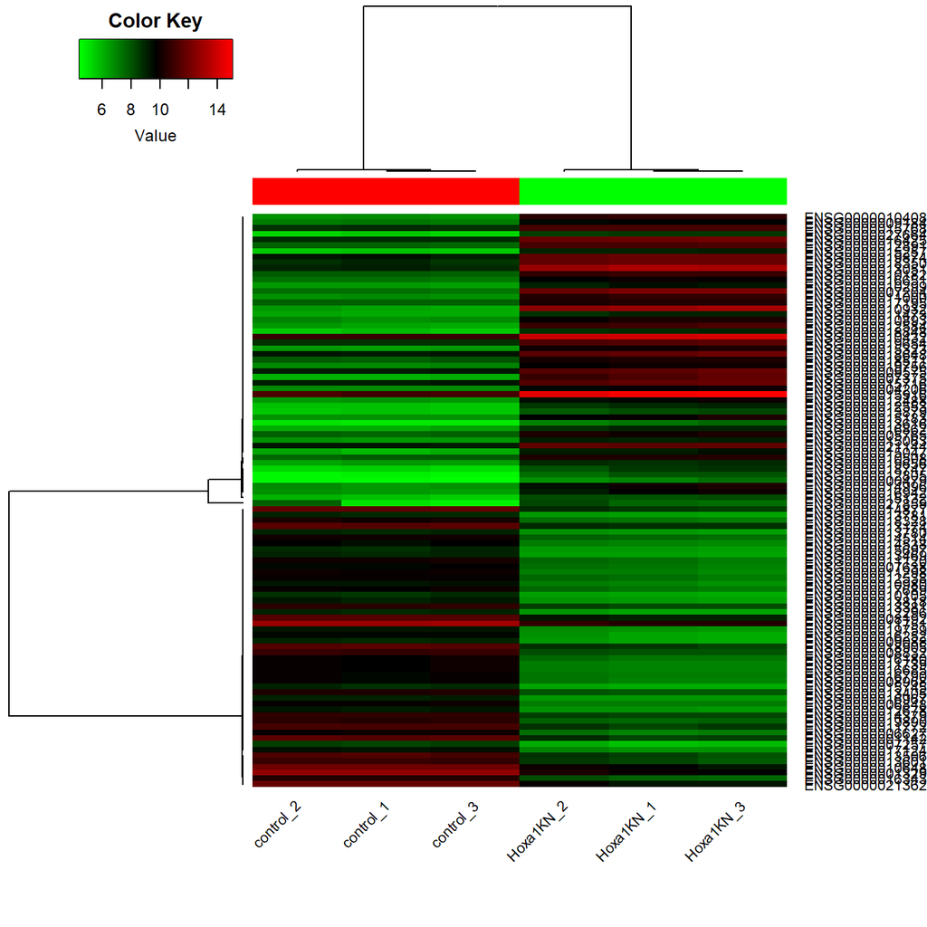

```r
n = 100
hist.data <- assay(rlog.dds)
hist.data <- hist.data[order(apply(hist.data,1,sd), decreasing=TRUE),]
hist.data <- hist.data[1:n,]

unlist.data <- unlist(hist.data)
cutoff.up.lim <- median(unlist.data) + 4 * sd(unlist.data)
cutoff.down.lim <- median(unlist.data) - 4 * sd(unlist.data)
hist.data[hist.data > cutoff.up.lim] <- cutoff.up.lim
hist.data[hist.data < cutoff.down.lim] <- cutoff.down.lim

lmat = rbind(c(5,4),c(0,1),c(3,2))
lwid = c(1.5,4)
lhei = c(1,.2,4)

heatmap.2(
    hist.data,
    distfun = dist2,
    hclustfun=hclust2,
    col=greenred(75), density.info="none", trace="none", scale="none", keysize=.5
    ,key=T, symkey=F
    ,ColSideColors=c('red','red','red', 'green', 'green', 'green')
    ,margins=c(8,8)
    ,cexRow=1
    ,srtCol=45
    ,cexCol=1
    ,lmat = lmat, lwid = lwid, lhei = lhei
    )
```

# 4. DESeq2

## 4.1 Run Deseq2 again

We did pre-filtering in section 2. It is better to run Deseq anagin.

```r
dds <- DESeq(dds)
```

## 4.2 Cut result by FDR = 0.05 and abs(lfc) > 1

```r
res <- results(dds, alpha=0.05, lfcThreshold=1)
#res05inc <- results(dds, alpha=0.05, lfcThreshold=1, altHypothesis="greater")
#res05decs <- results(dds, alpha=0.05, lfcThreshold=1, altHypothesis="less")

res <- res[order(abs( res$log2FoldChange), decreasing=TRUE),]
#res05inc <- res05inc[order(abs( res05inc$log2FoldChange), decreasing=TRUE),]
#res05decs <- res05decs[order(abs( res05decs$log2FoldChange), decreasing=TRUE),]

colnames(res)
```

```
## [1] "baseMean"       "log2FoldChange" "lfcSE"          "stat"
## [5] "pvalue"         "padj"
```

```r
summary(res)
```

```
##
## out of 14933 with nonzero total read count
## adjusted p-value < 0.05
## LFC > 1.00 (up)    : 397, 2.7%
## LFC < -1.00 (down) : 533, 3.6%
## outliers [1]       : 2, 0.013%
## low counts [2]     : 0, 0%
## (mean count < 1)
## [1] see 'cooksCutoff' argument of ?results
## [2] see 'independentFiltering' argument of ?results
```

```r
#summary(res05inc)
#summary(res05decs)
```

# 5. Using GOStat package to do enrichment tests

## 5.1 Map Ids

```r
res$symbol = gsub(" ","",row.names(res))
res$entrez = mapIds(org.Hs.eg.db,
                     keys=row.names(res),
                     column="ENTREZID",
                     keytype="ENSEMBL",
                     multiVals="first")
res$goids = mapIds(org.Hs.eg.db,
                     keys=row.names(res),
                     column="GO",
                     keytype="ENSEMBL",
                     multiVals="first")
res$name =   mapIds(org.Hs.eg.db,
                     keys=row.names(res),
                     column="GENENAME",
                     keytype="ENSEMBL",
                     multiVals="first")
head(res)
```

```
## log2 fold change (MLE): condition Hoxa1KN vs control
## Wald test p-value: condition Hoxa1KN vs control
## DataFrame with 6 rows and 10 columns
##                         baseMean    log2FoldChange             lfcSE
##                        <numeric>         <numeric>         <numeric>
## ENSG00000128052 161.159172386435  8.84719628700738  1.03976348097027
## ENSG00000004799 99.9726091565586  8.15382043215579  1.04477531171062
## ENSG00000141668 45.3164490590654   7.8961573039556  1.21663103339902
## ENSG00000109321 4009.16292552262  7.49542831329459 0.280814399718235
## ENSG00000131737 14.4818879118689 -7.40420592455903  1.28557258403763
## ENSG00000162892 25.6884905685018  7.07322427773159  1.24274242572885
##                              stat                pvalue
##                         <numeric>             <numeric>
## ENSG00000128052  7.54709742227592  4.45065668374496e-14
## ENSG00000004799  6.84723342135906   7.5291814306716e-12
## ENSG00000141668  5.66824050566022  1.44271361523339e-08
## ENSG00000109321  23.1306810470261 2.27510554617329e-118
## ENSG00000131737 -4.98159808639133  6.30613057591039e-07
## ENSG00000162892   4.8869533637831  1.02408339652627e-06
##                                 padj          symbol      entrez
##                            <numeric>     <character> <character>
## ENSG00000128052 1.67809987234839e-12 ENSG00000128052        3791
## ENSG00000004799 2.54916571295596e-10 ENSG00000004799        5166
## ENSG00000141668   3.938054294159e-07 ENSG00000141668      147381
## ENSG00000109321 1.9982118182302e-115 ENSG00000109321         374
## ENSG00000131737 1.55888800710129e-05 ENSG00000131737        3885
## ENSG00000162892 2.47741341984078e-05 ENSG00000162892       11009
##                       goids                            name
##                 <character>                     <character>
## ENSG00000128052  GO:0001525   kinase insert domain receptor
## ENSG00000004799  GO:0004672 pyruvate dehydrogenase kinase 4
## ENSG00000141668  GO:0005615          cerebellin 2 precursor
## ENSG00000109321  GO:0000139                    amphiregulin
## ENSG00000131737  GO:0005198                      keratin 34
## ENSG00000162892  GO:0005125                  interleukin 24
```

## 5.2 Get Up, Down and Universal Ids

** deseq2::results ** function is not able to ‘filtering’ genes. To filter genes, we need following code.

```r
up.idx <- which(res$padj<0.05 & res$log2FoldChange > 1)
up.entrez.id <- unique(res[up.idx, 'entrez'])

down.idx <- which(res$padj<0.05 & res$log2FoldChange < -1)
down.entrez.id <- unique(res[down.idx, 'entrez'])

length(up.idx)
```

```
## [1] 397
```

```r
length(down.idx)
```

```
## [1] 533
```

```r
universeGenes <-  unique(res$entrez)
```

## 5.3 Up gene GO analysis

### BP

```r
params <- new("GOHyperGParams",
     geneIds=up.entrez.id,
     universeGeneIds=universeGenes,
     annotation="org.Hs.eg.db",
     ontology="BP",
     pvalueCutoff=0.001,
     conditional=FALSE,
     testDirection="over")

hgOver <- hyperGTest(params)
summary(hgOver)[1:10,c("GOBPID","Pvalue","Term")]
```

```
##        GOBPID       Pvalue                                    Term
## 1  GO:0007166 4.793450e-22 cell surface receptor signaling pathway
## 2  GO:0023052 2.499938e-20                               signaling
## 3  GO:0007165 3.955445e-20                     signal transduction
## 4  GO:0007154 3.183789e-19                      cell communication
## 5  GO:0050896 4.252050e-19                    response to stimulus
## 6  GO:0030334 4.889597e-18            regulation of cell migration
## 7  GO:2000145 2.051733e-17             regulation of cell motility
## 8  GO:0042221 3.945641e-17                    response to chemical
## 9  GO:0040012 6.393966e-17                regulation of locomotion
## 10 GO:0051716 1.042820e-16           cellular response to stimulus
```

### CC

```r
params <- new("GOHyperGParams",
     geneIds=up.entrez.id,
     universeGeneIds=universeGenes,
     annotation="org.Hs.eg.db",
     ontology="CC",
     pvalueCutoff=0.001,
     conditional=FALSE,
     testDirection="over")

hgOver <- hyperGTest(params)
summary(hgOver)[1:10,c("GOCCID","Pvalue","Term")]
```

```
##        GOCCID       Pvalue                                   Term
## 1  GO:0044459 1.942307e-14                   plasma membrane part
## 2  GO:0005886 7.724208e-14                        plasma membrane
## 3  GO:0005887 1.621037e-13  integral component of plasma membrane
## 4  GO:0071944 1.646847e-13                         cell periphery
## 5  GO:0031226 1.831324e-13 intrinsic component of plasma membrane
## 6  GO:0031224 7.076382e-09        intrinsic component of membrane
## 7  GO:0009986 7.496922e-09                           cell surface
## 8  GO:0044425 1.673117e-08                          membrane part
## 9  GO:0016021 3.025075e-08         integral component of membrane
## 10 GO:0031012 4.646985e-07                   extracellular matrix
```

### MF

```r
params <- new("GOHyperGParams",
     geneIds=up.entrez.id,
     universeGeneIds=universeGenes,
     annotation="org.Hs.eg.db",
     ontology="MF",
     pvalueCutoff=0.001,
     conditional=FALSE,
     testDirection="over")

hgOver <- hyperGTest(params)
summary(hgOver)[1:10,c("GOMFID","Pvalue","Term")]
```

```
##        GOMFID       Pvalue                                      Term
## 1  GO:0048018 4.001024e-19                  receptor ligand activity
## 2  GO:0030545 5.755226e-18               receptor regulator activity
## 3  GO:0005125 1.179937e-14                         cytokine activity
## 4  GO:0005102 4.131686e-14                signaling receptor binding
## 5  GO:0038023 9.099414e-11               signaling receptor activity
## 6  GO:0060089 9.099414e-11             molecular transducer activity
## 7  GO:0004871 1.548755e-10                signal transducer activity
## 8  GO:0008083 7.973314e-10                    growth factor activity
## 9  GO:0098772 6.425121e-09              molecular function regulator
## 10 GO:0004888 1.418023e-08 transmembrane signaling receptor activity
```

## 5.4 Down gene GO analysis

### BP

```r
params <- new("GOHyperGParams",
     geneIds=down.entrez.id,
     universeGeneIds=universeGenes,
     annotation="org.Hs.eg.db",
     ontology="BP",
     pvalueCutoff=0.001,
     conditional=FALSE,
     testDirection="over")

hgOver <- hyperGTest(params)
summary(hgOver)[1:10,c("GOBPID","Pvalue","Term")]
```

```
##        GOBPID       Pvalue                                 Term
## 1  GO:0000278 2.906737e-43                   mitotic cell cycle
## 2  GO:0007049 6.176427e-42                           cell cycle
## 3  GO:0022402 3.971963e-38                   cell cycle process
## 4  GO:1903047 1.428219e-37           mitotic cell cycle process
## 5  GO:0051301 2.382023e-35                        cell division
## 6  GO:0007059 5.971734e-35               chromosome segregation
## 7  GO:0098813 2.455477e-31       nuclear chromosome segregation
## 8  GO:0000280 1.047413e-30                     nuclear division
## 9  GO:0000819 2.618682e-30         sister chromatid segregation
## 10 GO:0000070 2.016329e-28 mitotic sister chromatid segregation
```

### CC

```r
params <- new("GOHyperGParams",
     geneIds=down.entrez.id,
     universeGeneIds=universeGenes,
     annotation="org.Hs.eg.db",
     ontology="CC",
     pvalueCutoff=0.001,
     conditional=FALSE,
     testDirection="over")

hgOver <- hyperGTest(params)
summary(hgOver)[1:10,c("GOCCID","Pvalue","Term")]
```

```
##        GOCCID       Pvalue                                         Term
## 1  GO:0044430 2.445460e-22                            cytoskeletal part
## 2  GO:0000793 4.123785e-22                         condensed chromosome
## 3  GO:0005819 1.037259e-21                                      spindle
## 4  GO:0043228 1.085093e-21               non-membrane-bounded organelle
## 5  GO:0043232 1.085093e-21 intracellular non-membrane-bounded organelle
## 6  GO:0005856 8.511591e-21                                 cytoskeleton
## 7  GO:0000779 1.221715e-19     condensed chromosome, centromeric region
## 8  GO:0000775 1.316433e-18               chromosome, centromeric region
## 9  GO:0015630 2.704579e-18                     microtubule cytoskeleton
## 10 GO:0098687 4.558799e-17                           chromosomal region
```

### MF

```r
params <- new("GOHyperGParams",
     geneIds=down.entrez.id,
     universeGeneIds=universeGenes,
     annotation="org.Hs.eg.db",
     ontology="MF",
     pvalueCutoff=0.001,
     conditional=FALSE,
     testDirection="over")

hgOver <- hyperGTest(params)
summary(hgOver)[1:10,c("GOMFID","Pvalue","Term")]
```

```
##        GOMFID       Pvalue                                       Term
## 1  GO:0008092 1.530673e-11               cytoskeletal protein binding
## 2  GO:0008017 8.584498e-10                        microtubule binding
## 3  GO:0035639 4.760803e-09 purine ribonucleoside triphosphate binding
## 4  GO:0005524 9.388077e-09                                ATP binding
## 5  GO:0000166 1.203291e-08                         nucleotide binding
## 6  GO:1901265 1.241471e-08               nucleoside phosphate binding
## 7  GO:0032555 1.409130e-08              purine ribonucleotide binding
## 8  GO:0032553 2.091190e-08                     ribonucleotide binding
## 9  GO:0017076 2.231990e-08                  purine nucleotide binding
## 10 GO:0003779 2.380674e-08                              actin binding
```

# 6. Pathway: Gage

## 6.1 Gage anaylsis using kegg

```r
library(gageData)
resLFC = res$log2FoldChange
names(resLFC) = res$entrez
data(kegg.sets.hs)
data(sigmet.idx.hs)
kegg.sets.hs = kegg.sets.hs[sigmet.idx.hs]

kres = gage(resLFC, gsets=kegg.sets.hs, same.dir=TRUE)
lapply(kres, head)
```

```
## $greater
##                                          p.geomean stat.mean        p.val
## hsa04640 Hematopoietic cell lineage   0.0007539648  3.277202 0.0007539648
## hsa04142 Lysosome                     0.0019987583  2.911015 0.0019987583
## hsa00140 Steroid hormone biosynthesis 0.0027606327  2.930072 0.0027606327
## hsa04630 Jak-STAT signaling pathway   0.0042840578  2.656489 0.0042840578
## hsa04062 Chemokine signaling pathway  0.0152602177  2.175176 0.0152602177
## hsa04740 Olfactory transduction       0.0197052511  2.133087 0.0197052511
##                                           q.val set.size         exp1
## hsa04640 Hematopoietic cell lineage   0.1213883       51 0.0007539648
## hsa04142 Lysosome                     0.1481540      112 0.0019987583
## hsa00140 Steroid hormone biosynthesis 0.1481540       26 0.0027606327
## hsa04630 Jak-STAT signaling pathway   0.1724333      101 0.0042840578
## hsa04062 Chemokine signaling pathway  0.4580682      136 0.0152602177
## hsa04740 Olfactory transduction       0.4580682       28 0.0197052511
##
## $less
##                                      p.geomean stat.mean        p.val
## hsa04110 Cell cycle               6.304320e-06 -4.465143 6.304320e-06
## hsa03030 DNA replication          6.348730e-05 -4.063738 6.348730e-05
## hsa04114 Oocyte meiosis           1.570550e-04 -3.668918 1.570550e-04
## hsa03440 Homologous recombination 3.724348e-03 -2.780994 3.724348e-03
## hsa03013 RNA transport            4.061021e-03 -2.671669 4.061021e-03
## hsa00240 Pyrimidine metabolism    4.794495e-03 -2.617815 4.794495e-03
##                                         q.val set.size         exp1
## hsa04110 Cell cycle               0.001014996      119 6.304320e-06
## hsa03030 DNA replication          0.005110728       36 6.348730e-05
## hsa04114 Oocyte meiosis           0.008428617       99 1.570550e-04
## hsa03440 Homologous recombination 0.128652283       28 3.724348e-03
## hsa03013 RNA transport            0.128652283      142 4.061021e-03
## hsa00240 Pyrimidine metabolism    0.128652283       93 4.794495e-03
##
## $stats
##                                       stat.mean     exp1
## hsa04640 Hematopoietic cell lineage    3.277202 3.277202
## hsa04142 Lysosome                      2.911015 2.911015
## hsa00140 Steroid hormone biosynthesis  2.930072 2.930072
## hsa04630 Jak-STAT signaling pathway    2.656489 2.656489
## hsa04062 Chemokine signaling pathway   2.175176 2.175176
## hsa04740 Olfactory transduction        2.133087 2.133087
```

```r
k_pathways_Up = data.frame(id=rownames(kres$greater), kres$greater) %>%
  tbl_df() %>%
  filter(row_number()<=5) %>%
  .$id %>%
  as.character()

k_pathways_Down = data.frame(id=rownames(kres$less), kres$less) %>%
  tbl_df() %>%
  filter(row_number()<=5) %>%
  .$id %>%
  as.character()

k_Up_ids = unique(substr(k_pathways_Up, start=1, stop=8))
k_Down_ids = unique(substr(k_pathways_Down, start=1, stop=8))
```

### Up regulated pathways

[figure not shown]

[figure not shown]

[figure not shown]

[figure not shown]

[figure not shown]

[figure not shown]

```r
pathview(gene.data=resLFC, pathway.id=k_Up_ids, species="hsa", kegg.dir = "PathviewResult/Up/", new.signature=FALSE)
for(f in k_Up_ids){
  f <- paste0(f,'.pathview.png')
  knitr::include_graphics(f)
}

knitr::include_graphics(f)
```

### Down regulated pathways

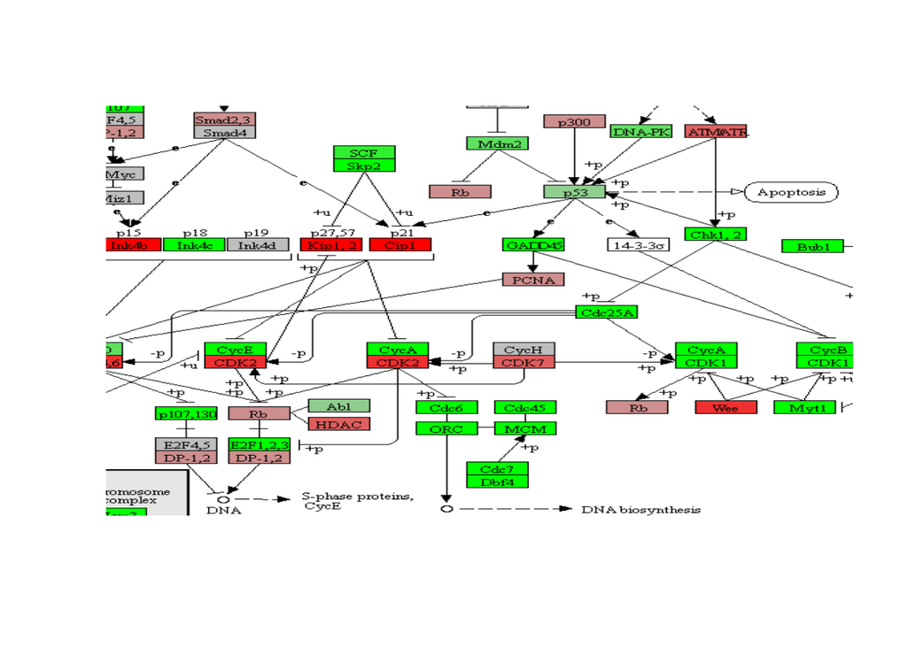

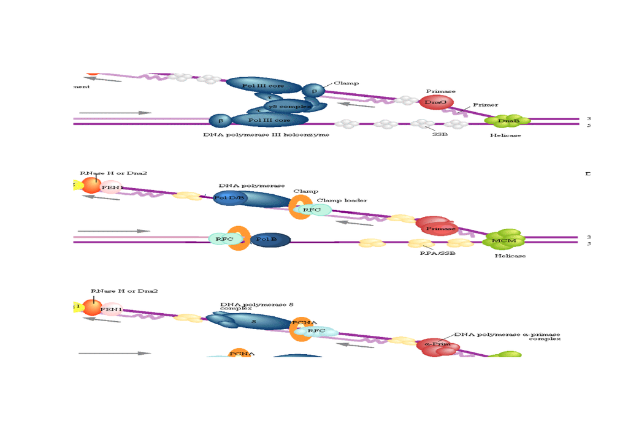

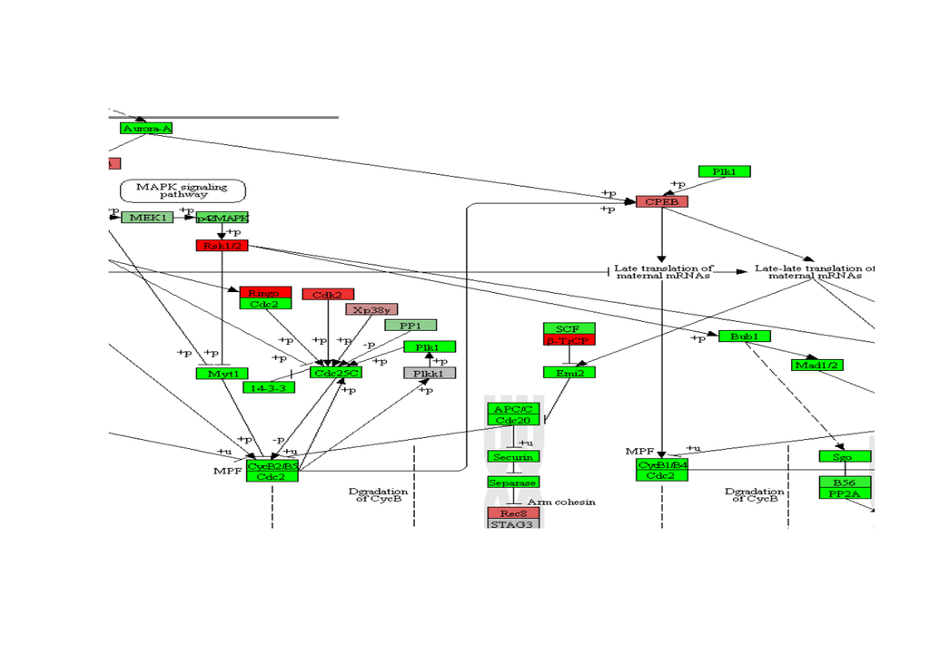

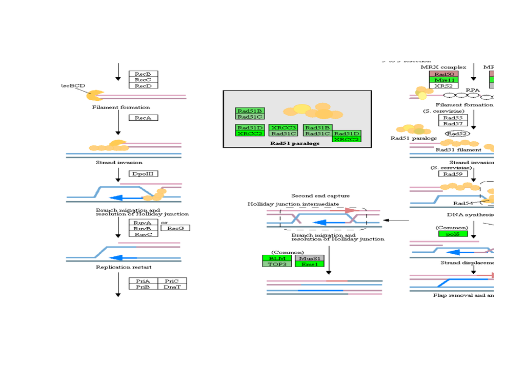

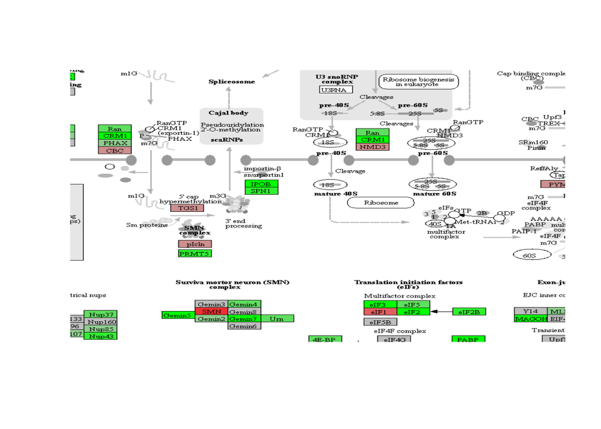

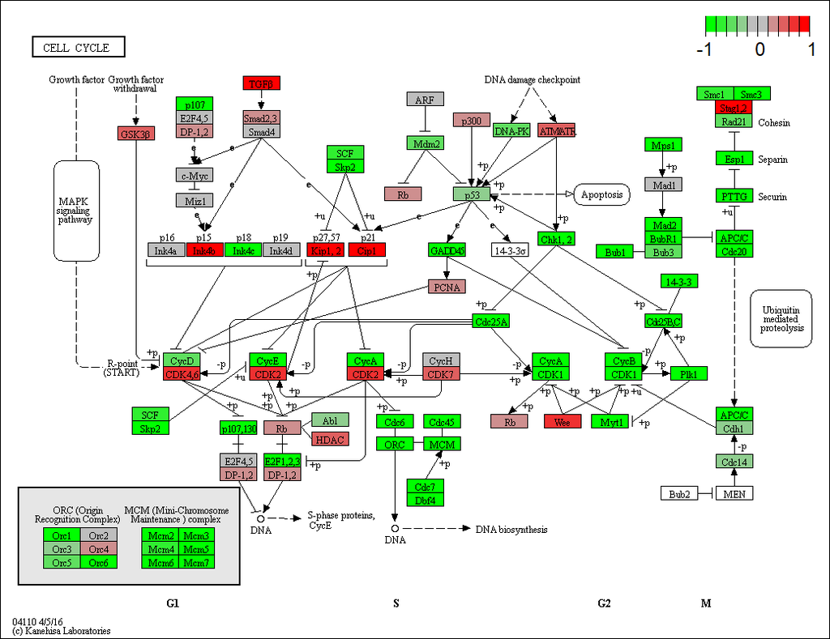

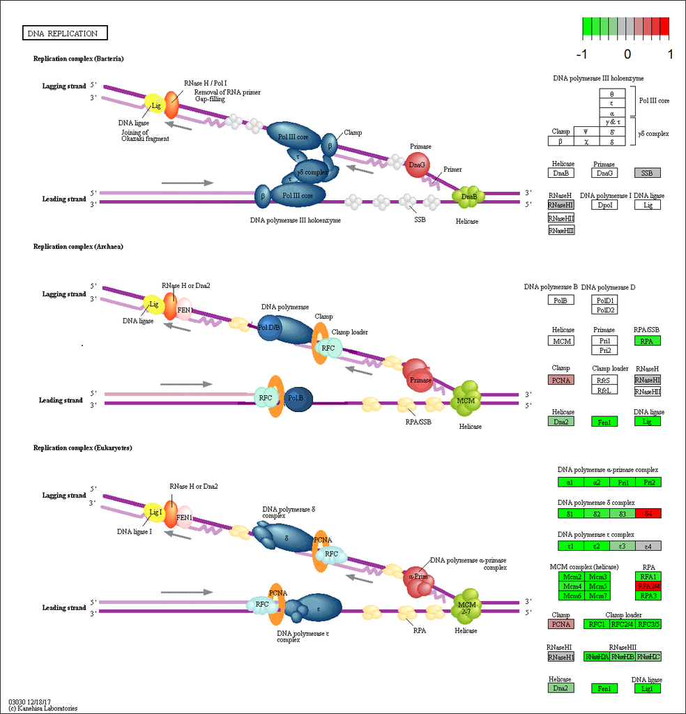

[figure not shown]

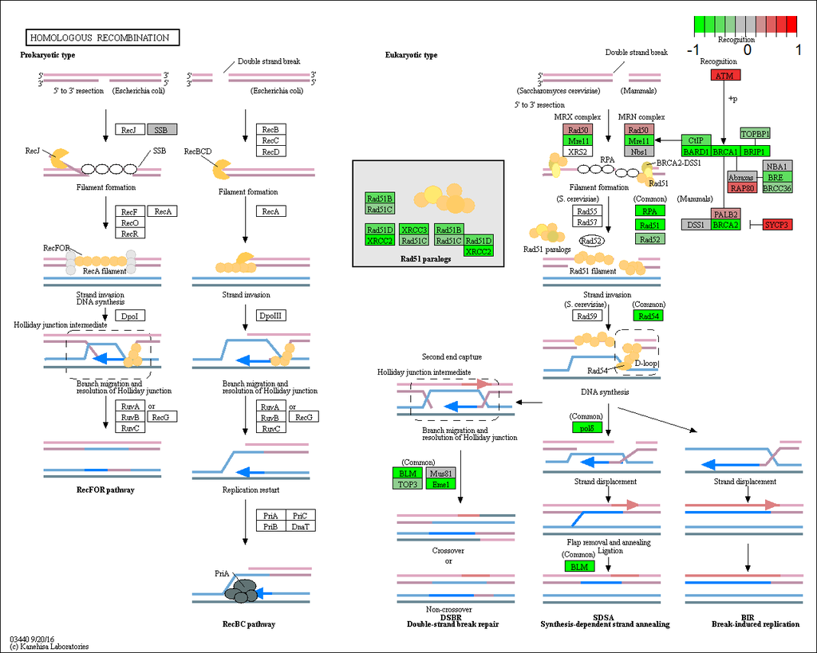

[figure not shown]

```r
pathview(gene.data=resLFC, pathway.id=k_Down_ids, species="hsa", kegg.dir = "PathviewResult/Down/", new.signature=FALSE)
for(f in k_Down_ids){
  f <- paste0(f,'.pathview.png')
  img <- readPNG(f)
  plot.new()
  rasterImage(img,-0.5, -0.3, 1.5, 1.3)
}
```

## 6.2 Gage anaylsis using GO

```r
data(go.sets.hs)
data(go.subs.hs)
resLFC = res$log2FoldChange

gobpsets = go.sets.hs[go.subs.hs$BP]
goccsets = go.sets.hs[go.subs.hs$CC]
gomfsets = go.sets.hs[go.subs.hs$MF]

GoLFC <- resLFC
names(GoLFC) <- res$entrez
head(GoLFC)
```

```
##      3791      5166    147381       374      3885     11009
##  8.847196  8.153820  7.896157  7.495428 -7.404206  7.073224
```

```r
gobpres <- gage(GoLFC, gsets=gobpsets, same.dir=TRUE)
goccres <- gage(GoLFC, gsets=goccsets, same.dir=TRUE)
gomfres <- gage(GoLFC, gsets=gomfsets, same.dir=TRUE)
```

### bp result

```r
lapply(gobpres, head)
```

```
## $greater
##                                                         p.geomean
## GO:0007156 homophilic cell adhesion                  7.911965e-06
## GO:0016337 cell-cell adhesion                        4.509012e-05
## GO:0016339 calcium-dependent cell-cell adhesion      2.652469e-04
## GO:0060429 epithelium development                    9.059091e-04
## GO:0008285 negative regulation of cell proliferation 1.118479e-03
## GO:0007268 synaptic transmission                     1.119570e-03
##                                                      stat.mean
## GO:0007156 homophilic cell adhesion                   4.416123
## GO:0016337 cell-cell adhesion                         3.942404
## GO:0016339 calcium-dependent cell-cell adhesion       3.718694
## GO:0060429 epithelium development                     3.129375
## GO:0008285 negative regulation of cell proliferation  3.066797
## GO:0007268 synaptic transmission                      3.065451
##                                                             p.val
## GO:0007156 homophilic cell adhesion                  7.911965e-06
## GO:0016337 cell-cell adhesion                        4.509012e-05
## GO:0016339 calcium-dependent cell-cell adhesion      2.652469e-04
## GO:0060429 epithelium development                    9.059091e-04
## GO:0008285 negative regulation of cell proliferation 1.118479e-03
## GO:0007268 synaptic transmission                     1.119570e-03
##                                                           q.val set.size
## GO:0007156 homophilic cell adhesion                  0.03088040      110
## GO:0016337 cell-cell adhesion                        0.08799337      310
## GO:0016339 calcium-dependent cell-cell adhesion      0.34508621       25
## GO:0060429 epithelium development                    0.51901023      450
## GO:0008285 negative regulation of cell proliferation 0.51901023      422
## GO:0007268 synaptic transmission                     0.51901023      477
##                                                              exp1
## GO:0007156 homophilic cell adhesion                  7.911965e-06
## GO:0016337 cell-cell adhesion                        4.509012e-05
## GO:0016339 calcium-dependent cell-cell adhesion      2.652469e-04
## GO:0060429 epithelium development                    9.059091e-04
## GO:0008285 negative regulation of cell proliferation 1.118479e-03
## GO:0007268 synaptic transmission                     1.119570e-03
##
## $less
##                                             p.geomean stat.mean
## GO:0000279 M phase                       5.871516e-17 -8.447365
```

[output cut: 13 more lines]

```
## GO:0000279 M phase                            481 5.871516e-17
## GO:0048285 organelle fission                  367 2.256703e-16
## GO:0000280 nuclear division                   343 3.718509e-16
## GO:0007067 mitosis                            343 3.718509e-16
## GO:0000087 M phase of mitotic cell cycle      353 1.116607e-15
## GO:0007059 chromosome segregation             137 1.528101e-12
##
## $stats
##                                                      stat.mean     exp1
## GO:0007156 homophilic cell adhesion                   4.416123 4.416123
## GO:0016337 cell-cell adhesion                         3.942404 3.942404
## GO:0016339 calcium-dependent cell-cell adhesion       3.718694 3.718694
## GO:0060429 epithelium development                     3.129375 3.129375
## GO:0008285 negative regulation of cell proliferation  3.066797 3.066797
## GO:0007268 synaptic transmission                      3.065451 3.065451
```

### cc result

```r
lapply(goccres, head)
```

```
## $greater
##                                                    p.geomean stat.mean
## GO:0044437 vacuolar part                         0.002090270  2.880106
## GO:0005773 vacuole                               0.006550804  2.487623
## GO:0005774 vacuolar membrane                     0.007284314  2.456827
## GO:0031012 extracellular matrix                  0.007690794  2.430055
## GO:0008328 ionotropic glutamate receptor complex 0.008322229  2.499446
## GO:0005770 late endosome                         0.010320438  2.330410
##                                                        p.val     q.val
## GO:0044437 vacuolar part                         0.002090270 0.7519211
## GO:0005773 vacuole                               0.006550804 0.7519211
## GO:0005774 vacuolar membrane                     0.007284314 0.7519211
## GO:0031012 extracellular matrix                  0.007690794 0.7519211
## GO:0008328 ionotropic glutamate receptor complex 0.008322229 0.7519211
## GO:0005770 late endosome                         0.010320438 0.7519211
##                                                  set.size        exp1
## GO:0044437 vacuolar part                              217 0.002090270
## GO:0005773 vacuole                                    346 0.006550804
## GO:0005774 vacuolar membrane                          161 0.007284314
## GO:0031012 extracellular matrix                       318 0.007690794
## GO:0008328 ionotropic glutamate receptor complex       22 0.008322229
## GO:0005770 late endosome                              137 0.010320438
##
## $less
##                                                p.geomean stat.mean
## GO:0000775 chromosome, centromeric region   1.475160e-11 -6.929784
## GO:0000793 condensed chromosome             2.656185e-11 -6.812436
## GO:0005819 spindle                          2.790565e-11 -6.718646
## GO:0044427 chromosomal part                 8.204128e-10 -6.089657
## GO:0000777 condensed chromosome kinetochore 2.572434e-09 -6.202774
## GO:0000776 kinetochore                      2.596457e-09 -6.113828
##                                                    p.val        q.val
## GO:0000775 chromosome, centromeric region   1.475160e-11 4.474206e-09
## GO:0000793 condensed chromosome             2.656185e-11 4.474206e-09
## GO:0005819 spindle                          2.790565e-11 4.474206e-09
## GO:0044427 chromosomal part                 8.204128e-10 9.865464e-08
## GO:0000777 condensed chromosome kinetochore 2.572434e-09 1.876807e-07
## GO:0000776 kinetochore                      2.596457e-09 1.876807e-07
##                                             set.size         exp1
## GO:0000775 chromosome, centromeric region        144 1.475160e-11
## GO:0000793 condensed chromosome                  156 2.656185e-11
## GO:0005819 spindle                               230 2.790565e-11
## GO:0044427 chromosomal part                      477 8.204128e-10
## GO:0000777 condensed chromosome kinetochore       81 2.572434e-09
## GO:0000776 kinetochore                           103 2.596457e-09
##
## $stats
##                                                  stat.mean     exp1
## GO:0044437 vacuolar part                          2.880106 2.880106
## GO:0005773 vacuole                                2.487623 2.487623
## GO:0005774 vacuolar membrane                      2.456827 2.456827
## GO:0031012 extracellular matrix                   2.430055 2.430055
## GO:0008328 ionotropic glutamate receptor complex  2.499446 2.499446
## GO:0005770 late endosome                          2.330410 2.330410
```

### mf result

```r
lapply(gomfres, head)
```

```
## $greater
##                                                                                                            p.geomean
## GO:0005125 cytokine activity                                                                            3.334801e-05
## GO:0004888 transmembrane signaling receptor activity                                                    7.879236e-05
## GO:0000981 sequence-specific DNA binding RNA polymerase II transcription factor activity                6.789711e-04
## GO:0004930 G-protein coupled receptor activity                                                          1.396354e-03
## GO:0033764 steroid dehydrogenase activity, acting on the CH-OH group of donors, NAD or NADP as acceptor 1.794850e-03
## GO:0005509 calcium ion binding                                                                          2.108240e-03
##                                                                                                         stat.mean
## GO:0005125 cytokine activity                                                                             4.091020
## GO:0004888 transmembrane signaling receptor activity                                                     3.796441
## GO:0000981 sequence-specific DNA binding RNA polymerase II transcription factor activity                 3.232441
## GO:0004930 G-protein coupled receptor activity                                                           3.009935
## GO:0033764 steroid dehydrogenase activity, acting on the CH-OH group of donors, NAD or NADP as acceptor  3.134670
## GO:0005509 calcium ion binding                                                                           2.868455
##                                                                                                                p.val
## GO:0005125 cytokine activity                                                                            3.334801e-05
## GO:0004888 transmembrane signaling receptor activity                                                    7.879236e-05
## GO:0000981 sequence-specific DNA binding RNA polymerase II transcription factor activity                6.789711e-04
## GO:0004930 G-protein coupled receptor activity                                                          1.396354e-03
## GO:0033764 steroid dehydrogenase activity, acting on the CH-OH group of donors, NAD or NADP as acceptor 1.794850e-03
## GO:0005509 calcium ion binding                                                                          2.108240e-03
##                                                                                                              q.val
## GO:0005125 cytokine activity                                                                            0.02641162
## GO:0004888 transmembrane signaling receptor activity                                                    0.03120178
## GO:0000981 sequence-specific DNA binding RNA polymerase II transcription factor activity                0.17924837
## GO:0004930 G-protein coupled receptor activity                                                          0.23956157
## GO:0033764 steroid dehydrogenase activity, acting on the CH-OH group of donors, NAD or NADP as acceptor 0.23956157
## GO:0005509 calcium ion binding                                                                          0.23956157
##                                                                                                         set.size
## GO:0005125 cytokine activity                                                                                 109
## GO:0004888 transmembrane signaling receptor activity                                                         469
## GO:0000981 sequence-specific DNA binding RNA polymerase II transcription factor activity                     172
## GO:0004930 G-protein coupled receptor activity                                                               215
## GO:0033764 steroid dehydrogenase activity, acting on the CH-OH group of donors, NAD or NADP as acceptor       19
## GO:0005509 calcium ion binding                                                                               482
##                                                                                                                 exp1
## GO:0005125 cytokine activity                                                                            3.334801e-05
## GO:0004888 transmembrane signaling receptor activity                                                    7.879236e-05
## GO:0000981 sequence-specific DNA binding RNA polymerase II transcription factor activity                6.789711e-04
```

[output cut: 48 more lines]

```
## $stats
##                                                                                                         stat.mean
## GO:0005125 cytokine activity                                                                             4.091020
## GO:0004888 transmembrane signaling receptor activity                                                     3.796441
## GO:0000981 sequence-specific DNA binding RNA polymerase II transcription factor activity                 3.232441
## GO:0004930 G-protein coupled receptor activity                                                           3.009935
## GO:0033764 steroid dehydrogenase activity, acting on the CH-OH group of donors, NAD or NADP as acceptor  3.134670
## GO:0005509 calcium ion binding                                                                           2.868455
##                                                                                                             exp1
## GO:0005125 cytokine activity                                                                            4.091020
## GO:0004888 transmembrane signaling receptor activity                                                    3.796441
## GO:0000981 sequence-specific DNA binding RNA polymerase II transcription factor activity                3.232441
## GO:0004930 G-protein coupled receptor activity                                                          3.009935
## GO:0033764 steroid dehydrogenase activity, acting on the CH-OH group of donors, NAD or NADP as acceptor 3.134670
## GO:0005509 calcium ion binding                                                                          2.868455
```